# exploring & testing pybind11 metatrader expert incbars

### Researching the trading strategy (PETR4) - small profit fast mean reversion

Amost all is based on the book **Advances in Financial Machine Learning**

```
    https://www.amazon.com/Advances-Financial-Machine-Learning-Marcos/dp/1119482089
```

Money bars (Chapter 2) and most of data manipulations (indicators etc.) done in a C++ dll.

- The Dll
  - uses `CTalib` for tecnical indicators
  - uses `PytorchCpp` (Uses GPU) for fracdiff indicator (Chapter 4)
  - uses `BoostC++` for `circular_buffer` (all tick/bars buffers used)
  - has a python-interpreter embedded
  - can call any `Python` script passing C++ data by the grace of `pybind11` stl header library
    - the fastest possible way to use Python Metatrader (ref. missing)
  - also due `pybind11` is also a python module `incbars.pyd` (Python API)
    - can call exactly the same code Metatrader calls
  - why same C++ dll with a Python API?
    - Fastest way I imagined to research & deploy machine learning ideas
  - is already tested[1] and works well within Metatrader 5 (tick based on real ticks backtest)
    - [1]more tests should / must be written (I'm using C++ Google Tests unit testing)

For researching porpouses the python module `incbars.pyd` is used. The entire 2019 tick data for PETR4 is available/used.

#### The strategy

Using specific values - but **all parameters** can be set when calling C++

- buy or sell based on **6 bollinger bands** signals on money bars
  - buy when crossing bellow the lower band 1
  - sell when crossing above the upper band -1
- money bars are formed for each **500k negotiated** (tick analyses)
- try to profit in **15 minutes** (expire time) or leave
- sl is **100** tp is **50**
- use tripple-barrier for labelling (Chapter 3)
  - training samples are labelled 1
    - when profit >= tp or profit >= tp/2 at expire time
    - 0 when failed
- use event and previous 9 m.bars to form training features e. g.
  - number of ticks to form a money bar
  - time to ... .....
  - etc.
- use a extra tree classifier to predict based on signal features
  - if it is a valid entry

#### working on...

- Purging from the training samples information overlapping with testing samples
- Implement sample weights based on average uniqueness of sample

```python
import os
home = os.environ['USERPROFILE']
os.chdir(os.path.join(home, r'Projects\stocks\mt5\python'))
```

```python
import util
import pandas as pd
import datetime
import numpy as np
import importlib
import glob
from matplotlib import pylab as plt
from statsmodels.tsa.stattools import adfuller # stationarity test
import talib as ta
from numba import jit

from sklearn.ensemble import ExtraTreesClassifier
import pickle
from sklearn.metrics import accuracy_score, recall_score, confusion_matrix, classification_report
import sys
from scipy.stats import entropy
```

```python
os.chdir(os.path.join(home, r'Projects\stocks\data'))
```

```python
npticks = np.fromfile('PETR4_mqltick.bin', dtype=util.mqltick_dtype)
len(npticks)
```

```
15453392
```

```python
os.chdir(r'D:\Metatrader 5')
```

```python
# 6 bands, 10/2 first band, batch 5, 100k training samples
nbands = 6
bwindow = 10
stddevs = 1.25
batch = 10
ntraining = int(100e3)
ordersize = 25e3 # 25K BRL
sl = 100
tp = 50
nincrease = 0 # no increases in positions yet
lotsmin = 100.
ticksize = 0.01
tickvalue = 0.01
moneybar = 500e3 #  money bar size 1MM BRL #
isbacktest = False
symbol = "PETR4"
```

```python
import incbars # #importlib.reload(incbars) tried almost everything impossible reload without restarting kernel
```

```python
# (int nbands, int bbwindow, int batch_size, int ntraining,
#     double start_hour, double end_hour,
#     double ordersize, double stoploss, double targetprofit,
#     double lotsmin, double ticksize, double tickvalue,
#     double moneybar_size,
#    // ticks control
#    bool isbacktest, char *symbol, int symboln, int64_t mt5_timenow)
incbars.initialize(nbands, bwindow, stddevs,
                   batch, ntraining,
                   10.25, 16.5, 15./60., # 10:15 to 16:30 , expires in 0:15 min
                   ordersize, sl, tp, nincrease,
                   lotsmin, ticksize, tickvalue,
                   moneybar,
                   isbacktest, symbol, len(symbol), 0)
```

```python
incbars.buffersize(), incbars.buffertotal()
```

```
(1000000, 0)
```

```python
maxticks = int(4e6) # 10MM
maxticks
```

```
4000000
```

```python
nextime = 0
chuncksize = int(500e3) # ticks chunck size
```

```python
%%time
for i in range(maxticks//chuncksize):
    start = int(np.searchsorted(npticks['time_msc'], nextime))
    end = start+chuncksize
    nextime = incbars.addticks(npticks[start:end])
    overlap = chuncksize*(i+1)-end
    print(nextime, start, end, overlap)
    incbars.refresh()
```

```
1546956185485 0 500000 0
1547732525791 499999 999999 1
1548857772908 999998 1499998 2
1549967904233 1499995 1999995 5
1550680006857 1999989 2499989 11
1551878461188 2499988 2999988 12
1552662718079 2999986 3499986 14
1553252884447 3499985 3999985 15
Wall time: 2.38 s
```

```python
%%time
incbars.createxyvectors()
```

```
Wall time: 231 ms
```

```
83481
```

```python
bars = incbars.moneybars()[:incbars.buffertotal()]
len(bars)
```

```
168587
```

Time between money bars

```
[0.000000e+00 0.000000e+00 0.000000e+00 5.030000e-01 3.909140e+00
 1.185604e+03]
```

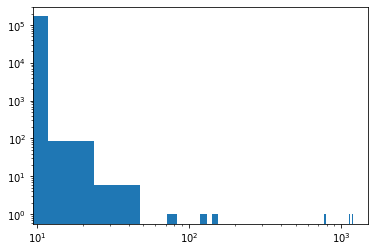

```python
plt.hist(bars['dtp'], bins=100);
plt.yscale('log')
plt.xscale('log')
print(np.percentile(bars['dtp'], [0, 10, 50, 90, 99, 100]))
```

X feature vector dimension

```python
xdim = incbars.xdim()
xdim
```

```
61
```

#### X y pairs or training samples

```python
%%time
X, y, lbsigns = incbars.getxyvectors()
```

```
Wall time: 557 ms
```

```python
lbsigns[:5]
```

```
array([(86, 0, 1, 0, 0, 127, -110., 43, 127),
       (86, 1, 1, 0, 0, 127, -110., 43, 127),
       (87, 2, 1, 1, 0, 105,   55., 44, 105),
       (87, 3, 1, 1, 0, 105,   55., 44, 105),
       (89, 1, 1, 1, 0, 105,   55., 46, 105)],
      dtype={'names':['twhen','band','sign','y','ninc','tdone','ret','inf_start','inf_end'], 'formats':['<u8','<i4','<i4','<i4','<i4','<u8','<f8','<u8','<u8'], 'offsets':[8,16,20,24,28,32,40,48,56], 'itemsize':64})
```

```python
lbsigns = pd.DataFrame.from_records(lbsigns)
lbsigns['twhen_ems'] = bars['emsc'][lbsigns['twhen']]
lbsigns['tdone_ems'] = bars['emsc'][lbsigns['tdone']]
lbsigns['dtclose'] = 0.001*(lbsigns['tdone_ems']-lbsigns['twhen_ems'] )
```

```python
lbsigns.dtypes, lbsigns.columns
```

```
(twhen         uint64
 band           int32
 sign           int32
 y              int32
 ninc           int32
 tdone         uint64
 ret          float64
 inf_start     uint64
 inf_end       uint64
 twhen_ems      int64
 tdone_ems      int64
 dtclose      float64
 dtype: object,
 Index(['twhen', 'band', 'sign', 'y', 'ninc', 'tdone', 'ret', 'inf_start',
        'inf_end', 'twhen_ems', 'tdone_ems', 'dtclose'],
       dtype='object'))
```

```python
np.percentile(lbsigns['ninc'], [0, 50, 100])
```

```
array([0., 0., 0.])
```

```python
len(X), len(y), len(lbsigns)
```

```
(83481, 83481, 83481)
```

```python
np.percentile(lbsigns['dtclose'], [0, 10, 50, 90, 99, 100])
# 1060/60 ~ 17.66 mins ok
# - also there is the Expert operational delay
# - also money bars are created in discret time interval
# making closure of positions based on its time aproximated
# 2385.897/60 ~ 39.7 mins due hiatus on ticks/bars ok very very rare
```

```
array([   8.213 ,  136.147 ,  874.766 ,  981.422 , 1060.2648, 2385.897 ])
```

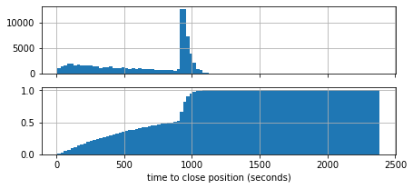

```python
fig, axes = plt.subplots(2, 1, sharex=True, figsize=(7,3))
axes[0].hist(lbsigns['dtclose'], bins=100);
#axes[0].set_yscale('log')
axes[1].hist(lbsigns['dtclose'], bins=100, density=True, cumulative=True);
axes[1].set_xlabel('time to close position (seconds)')
axes[0].grid()
axes[1].grid()
```

```python
X[-1], lbsigns['twhen'].iloc[-1], y[-1], lbsigns['band'].iloc[-1]
```

```
(array([ 32.   ,   0.   ,   0.702,   6.   ,   0.615,   0.   ,   0.   ,
          0.   ,   0.263,   5.   ,  -0.439,  -1.   ,   0.   ,   0.   ,
          1.008,   7.   ,   0.745,   2.   ,  48.   ,   0.   ,  12.105,
         34.   ,  11.097,  27.   ,   0.   ,   0.   ,   4.204,  27.   ,
         -7.901,  -7.   ,   0.   ,   0.   ,  13.072,  49.   ,   8.868,
         22.   ,   0.   ,   0.   ,  10.055,  30.   ,  -3.017, -19.   ,
          0.   ,   0.   ,   4.183,  17.   ,  -5.872, -13.   ,   0.   ,
          0.   ,   0.879,  14.   ,  -3.304,  -3.   ,   1.   ,   0.   ,
          8.511,  32.   ,   7.632,  18.   ,   0.   ]), 168542, 1, 0)
```

### Money bars time to form a bar

```python
dt = 0.001*(bars['emsc']-bars['smsc'])
```

```python
np.percentile(dt, [1, 10, 50, 90, 99, 100])
```

```
array([0.000000e+00, 0.000000e+00, 1.217000e+00, 2.672340e+01,
       6.867478e+01, 2.674347e+03])
```

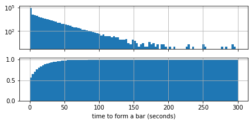

```python
fig, axes = plt.subplots(2, 1, sharex=True, figsize=(7,3))
axes[0].hist(dt, bins=100, range=[0, 300]);
axes[0].set_yscale('log')
axes[1].hist(dt, bins=100, range=[0, 300], density=True, cumulative=True);
axes[1].set_xlabel('time to form a bar (seconds)')
axes[0].grid()
axes[1].grid()
```

```python
#plt.plot(bars['nticks'], dt, '+r')
```

### Signal bands - 2 feature classes

- binary combined OR

```python
# max value for 6 class band signals combined
1<<0|1<<1|1<<2|1<<3|1<<4|1<<5, 0b111111, 1<<5
```

```
(63, 63, 32)
```

```python
X[0]
```

```
array([  0.   ,   0.   ,   4.427,  12.   , -23.378,  -8.   ,   0.   ,
        30.   ,  22.425,  25.   ,  17.998,  13.   ,   0.   ,   0.   ,
        34.222,  32.   ,  11.797,   7.   ,   0.   ,   0.   ,  61.376,
        23.   ,  27.154,  -9.   ,   0.   ,   0.   ,  28.012,  24.   ,
       -33.364,   1.   ,   0.   ,   0.   ,   0.173,  20.   , -27.839,
        -4.   ,   0.   ,   0.   ,   6.019,  20.   ,   5.846,   0.   ,
         0.   ,   0.   ,  15.531,  17.   ,   9.512,  -3.   ,   0.   ,
         0.   ,  34.49 ,  29.   ,  18.959,  12.   ,   3.   ,   0.   ,
        11.383,  30.   , -23.107,   1.   ,   0.   ])
```

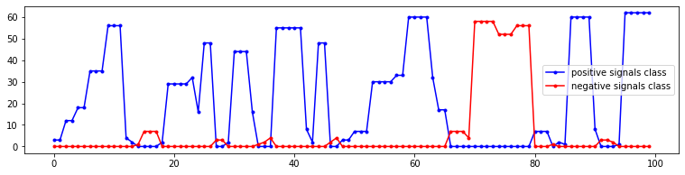

```python
plt.figure(figsize=(13,3))
plt.plot(X[:100, -7], '.-b',  label='positive signals class') # positive signals
plt.plot(X[:100, -6], '.-r', label='negative signals class') # negative ...
plt.legend()
```

```python
lbsigns['sign'].values[:30], lbsigns['band'].values[:30], lbsigns['twhen'].values[:30]
```

```
(array([ 1,  1,  1,  1,  1,  1,  1,  1,  1,  1,  1,  1,  1,  1, -1, -1, -1,
        -1,  1,  1,  1,  1,  1,  1,  1,  1,  1, -1, -1,  1]),
 array([0, 1, 2, 3, 1, 4, 0, 1, 5, 3, 4, 5, 2, 1, 0, 0, 1, 2, 1, 0, 2, 3,
        4, 5, 4, 4, 5, 0, 1, 1]),
 array([ 86,  86,  87,  87,  89,  89,  91,  91,  91,  94,  94,  94,  95,
         97,  99, 104, 104, 104, 108, 112, 112, 112, 112, 114, 116, 118,
        118, 120, 120, 124], dtype=uint64))
```

### Sample plot of bands and Signals

- in RED possible entries

```python
nfirst = 180
minplot, maxplot =  int(lbsigns['twhen'][0]),  int(lbsigns['twhen'][nfirst])
```

```python
mtype = 2
mdevs = stddevs
inc = 0.5
bbands = []
for i in range(nbands):
    ## weighted seams more meaning since i know each bar
    bbands.append(ta.BBANDS(bars['avgprice'], bwindow*inc, mdevs, mdevs, matype=mtype))
    inc += 0.5

bsignal_idxs = lbsigns['twhen'][:nfirst]
bsignal_ys = bars['avgprice'][bsignal_idxs]
```

```python
bwindow*inc
```

```
35.0
```

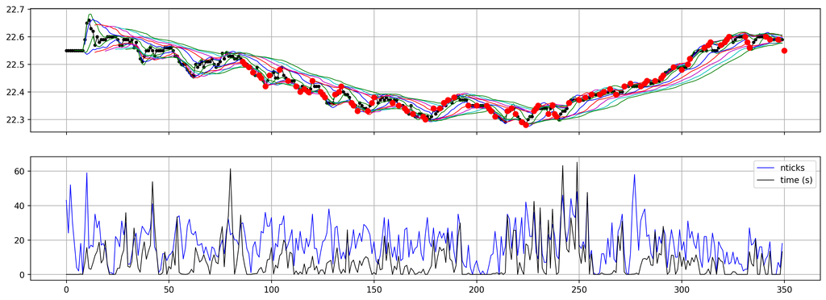

```python
fig, axes = plt.subplots(2, 1, sharex=True, figsize=(17,6), dpi=250)

axes[0].plot(bars['avgprice'][:maxplot], 'k', lw=0.8)
axes[0].plot(bars['avgprice'][:maxplot], '.k', lw=0.8)
lcolors = ['g', 'b', 'r', 'm', 'c', 'g']
for i in range(nbands):
    axes[0].plot(bbands[i][0][:maxplot], lcolors[i], lw=0.8)
    axes[0].plot(bbands[i][2][:maxplot],  lcolors[i], lw=0.8)
axes[0].grid()
axes[0].plot(bsignal_idxs, bsignal_ys, 'ro') # plot on over
#axes[0].set_ylim(22.5, 22.85)
axes[1].plot(bars['nticks'][:maxplot], 'b', lw=0.8, label='nticks')
axes[1].plot(0.001*(bars['emsc'][:maxplot]-bars['smsc'][:maxplot]), 'k', lw=0.8, label='time (s)')
axes[1].legend()
#axes[1].set_xlim(500, 790)
axes[1].grid()
# axes[2].plot((bars['bidh'][:maxplotbars]-bars['askl'][:maxplotbars]), 'k', lw=0.8, label='bid s')
# axes[2].set_ylim(0.05, -0.05)
```